# irisToolsHollarJ

Jadyn Hollar

2025-12-01

Introduction

This R Markdown is for my R package irisToolsHollarJ. The intent of this document is to document how my functions operate on the standard iris data set. This should be a fairly straightforward read with some inline code to exemplify how my functions work.

This document will feature:

- loading of my package
- preparing of iris data
- summary of iris data
- scatterplot
- Tukey outlier function

Load the Package

To start, I load my package in addition to ggplot2 for plotting.

```r
library(devtools)
devtools::load_all(".")
```

```
## ℹ Loading irisToolsHollarJ
```

```r
library(ggplot2)
```

Prepare the Package

For this I will be using my prepare_iris function that cleans and prepares the iris data. It also checks that it has all the required data and that species is a factor.

```r
clean_iris <- prepare_iris()
head(clean_iris)
```

```
##   Sepal.Length Sepal.Width Petal.Length Petal.Width Species
## 1          5.1         3.5          1.4         0.2  setosa
## 2          4.9         3.0          1.4         0.2  setosa
## 3          4.7         3.2          1.3         0.2  setosa
## 4          4.6         3.1          1.5         0.2  setosa
## 5          5.0         3.6          1.4         0.2  setosa
## 6          5.4         3.9          1.7         0.4  setosa
```

Summary

```r
summary_obj <- summarize_iris(clean_iris)

summary_obj
```

```
## $summary
## # A tibble: 3 × 4
##   Species    mean_sepal_length sd_sepal_length     n
##   <fct>                  <dbl>           <dbl> <int>
## 1 setosa                  5.01           0.352    50
## 2 versicolor              5.94           0.516    50
## 3 virginica               6.59           0.636    50
##
## $vars
## [1] "Sepal.Length" "Species"
##
## $call
## summarize_iris(data = clean_iris)
##
## attr(,"class")
## [1] "iris_summary"
```

```r
class(summary_obj)
```

```
## [1] "iris_summary"
```

Scatter plot

This function creates a scatter plot that plots the petal width and sepal length while categorizing them on color based on the species. To keep it simple, it uses the minimal theme.

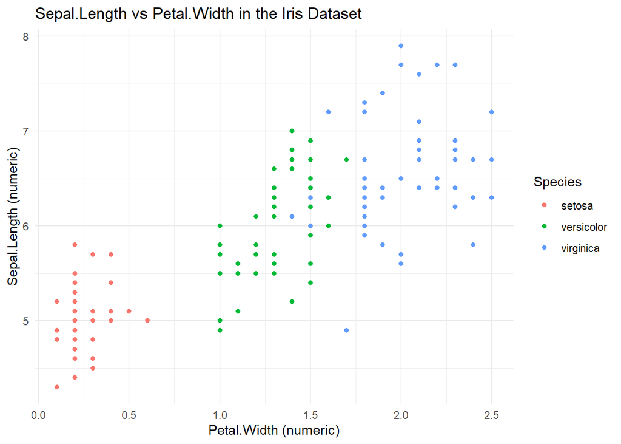

```r
plot_iris_scatter(
data = clean_iris,
xvar = "Petal.Width",
yvar = "Sepal.Length"
)
```

Tukey outlier

This function fixes bugs and also includes defensive checks by creating a matrix to run the function and determine if there are any significant outliers.

```r
set.seed(123)

test_matrix <- matrix(rnorm(50), nrow = 10)

test_matrix
```

```
##              [,1]       [,2]       [,3]        [,4]        [,5]
##  [1,] -0.56047565  1.2240818 -1.0678237  0.42646422 -0.69470698
##  [2,] -0.23017749  0.3598138 -0.2179749 -0.29507148 -0.20791728
##  [3,]  1.55870831  0.4007715 -1.0260044  0.89512566 -1.26539635
##  [4,]  0.07050839  0.1106827 -0.7288912  0.87813349  2.16895597
##  [5,]  0.12928774 -0.5558411 -0.6250393  0.82158108  1.20796200
##  [6,]  1.71506499  1.7869131 -1.6866933  0.68864025 -1.12310858
##  [7,]  0.46091621  0.4978505  0.8377870  0.55391765 -0.40288484
##  [8,] -1.26506123 -1.9666172  0.1533731 -0.06191171 -0.46665535
##  [9,] -0.68685285  0.7013559 -1.1381369 -0.30596266  0.77996512
## [10,] -0.44566197 -0.4727914  1.2538149 -0.38047100 -0.08336907
```

```r
tukey_multiple_safe(test_matrix)
```

```
##  [1] FALSE FALSE FALSE FALSE FALSE FALSE FALSE FALSE FALSE FALSE
```